# 01-visualizar-datos-presentacion

August 01, 2017

## Visualización de datos

## Introducción

Este tutorial te mostrará como visualizar datos usando la librería de R ggplot2. Este paquete fue creado for Hadley Wickman. La mayoría de los ejemplos de este tutorial están basados en el libro [R for data science](http://r4ds.had.co.nz)

## Data frames

Un data frame es una estructura de datos en R Un data frame es una tabla donde las columnas (columns) son variables y las filas (rows) son instancias, casos.

Nota: Este tipo de datos son datos limpios **tidy data** donde las columnas son siempre variables y las filas son instancias.

| estudiantes | edad | fac | estado |
| --- | --- | --- | --- |
| Juan | 22 | UNAM | Tabasco |
| Mildred | 18 | UV | Campeche |
| Sofía | 21 | preparatoria | Puebla |

## Prerequisites

```r
library(ggplot2)
```

If you run this code and get the error message "there is no package called ‘ggplot2’", you'll need to first install it, then run `library()` once again.

```r
install.packages("ggplot2")
library(ggplot2)
```

## A graphing template

Let's use our first graph to answer a question: Do cars with big engines use more fuel than cars with small engines?

You can test your answer with the `mpg` dataset in ggplot2, or `ggplot2::mpg`:

| manufacturer | model | displ | year | cyl | trans | drv | cty | hwy | fl | class |
| --- | --- | --- | --- | --- | --- | --- | --- | --- | --- | --- |
| audi | a4 | 1.8 | 1999 | 4 | auto(l5) | f | 18 | 29 | p | compact |
| audi | a4 | 1.8 | 1999 | 4 | manual(m5) | f | 21 | 29 | p | compact |
| audi | a4 | 2.0 | 2008 | 4 | manual(m6) | f | 20 | 31 | p | compact |
| audi | a4 | 2.0 | 2008 | 4 | auto(av) | f | 21 | 30 | p | compact |
| audi | a4 | 2.8 | 1999 | 6 | auto(l5) | f | 16 | 26 | p | compact |

## Gráficos

Muchas veces podemos usar números para tratar de entender un set de datos usando representaciones gráficas

Los autos con motores grandes consumen más gasolina?

## A graphing template (2)

Esta es una forma de describir un gráfico

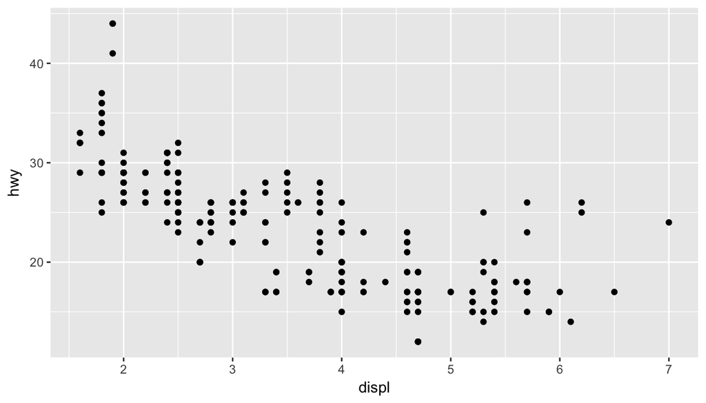

```r
ggplot(data = mpg) +
  geom_point(mapping = aes(x = displ, y = hwy))
```

## Gramática de gráficos

Aquí vamos a aprender la gramática de como construir un gráfico

1. Set de datos (data)
2. Especificar que variables y que instancias del set de datos queremos (mapping)
3. Luego especificamos que tipo de plot queremos (geom_point)
4. Por último agregamos propiedades del gráfico

```r
ggplot(data = mpg) +
  geom_point(mapping = aes(x = displ, y = hwy))
```

## Exercises

1. Run `ggplot(data = mpg)` what do you see?
2. What does the `drv` variable describe? Read the help for `?mpg` to find out.
3. Make a scatterplot of `hwy` vs `cyl`.
4. What happens if you make a scatterplot of `class` vs `drv`. Why is the plot not useful?

## Agregar "aesthetics" podemos agregar propiedades al gráfico

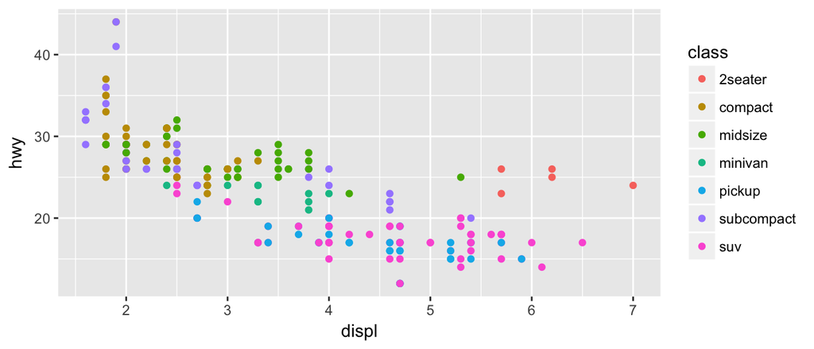

```r
ggplot(data = mpg) +
  geom_point(mapping = aes(x = displ, y = hwy,
                           color = class))
```

## Gráfico usando tamaño (mal ejemplo)

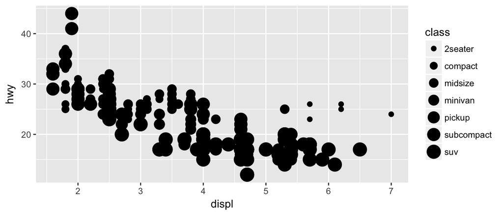

```r
ggplot(data = mpg) +
  geom_point(mapping = aes(x = displ, y = hwy,
                           size = class))
```

## Gráfico usando formas

```r
ggplot(data = mpg) +
  geom_point(mapping = aes(x = displ, y = hwy, shape = class))
```

## Gráfico usando formas

[figure not shown]

## Selección condicional (color)

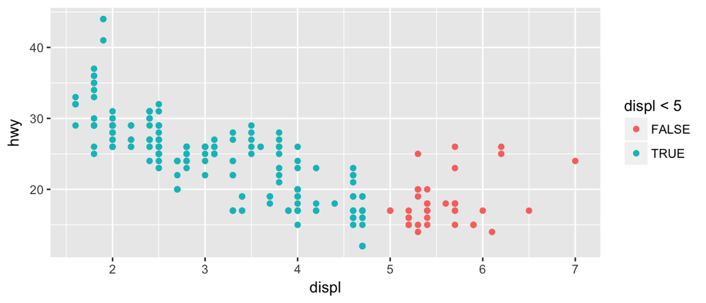

```r
ggplot(data = mpg) +
  geom_point(mapping = aes(x = displ, y = hwy, color = displ<5))
```

## Obtener ayuda

Escriban ?geom_point

```r
datos<-read.table("efectos_medicina_ALS.tsv", header = FALSE)
datos_ALS<-read.table("datos_ALS.tsv", header = FALSE)
```